# R for EPP research Assignment 5

Angelos-Miltiadis Krypotos

2016-05-12

## How to complete the assignment.

Please write your answers below each question, indicating clearly to which question (or subquestion) your answer refers to. I would prefer if you would send your answers as an html document using “knitr” and with all the code having been already executed. You can create html documents in R studio by just clicking the notepad icon on the top – For more info how to create notebooks in R studio see [here](https://support.rstudio.com/hc/en-us/articles/200552276-Creating-Notebooks-from-R-Scripts). If you want, you can also send your answers as an .R script. Lastly, writing your assignments in .doc or .docx is also OK, but because of automatised formatting etc., it would be hard for me to check whether the code is running properly or not.

Please go crazy with creating your functions. In the end, you can develop your function as much as you like. So, do it!

## Goals of the assignment

- Gain experience with creating your own functions in R

## Exercise 1

Check the lecture slides. In addition, go through [this webpage] (https://www.datacamp.com/community/tutorials/functions-in-r-a-tutorial) and [this chapter](http://adv-r.had.co.nz/Functional-programming.html). The latter one is advanced but you can get an idea about what are the good practices when writing R functions.

## Answer 1

Done

## Exercise 2

Make a function that takes as arguments two numeric vectors. The output of the function is the Bayes factors of a paired samples Bayesian t-test. Use the ‘Bayesfactor’ package for computing the Bayes factor.

## Answer 2

```r
library(BayesFactor)
MyBayesFunction <- function(x, y){
  res <- ttestBF(x, y, paired = TRUE)
  return(res)
}
```

```r
MyBayesFunction(rnorm(10, mean = 10), rnorm(10, mean = 12))
```

```
## Bayes factor analysis
## --------------
## [1] Alt., r=0.707 : 5.050213 ±0%
##
## Against denominator:
##   Null, mu = 0
## ---
## Bayes factor type: BFoneSample, JZS
```

## Exercise 3

Create a new function, as in Exercise 2, but now the output is the Bayes factor when the rscale is set to .707, and to 1. You have to make sure that the user knows which Bayes factor corresponds to which rscale.

## Answer 3

This is a way to do so but it is not the best way. The best way would be to use a recursive function but we have not talked about it in class.

```r
library(BayesFactor)
MyBayesFunction2 <- function(x, y){
  res707 <- ttestBF(x, y, paired = TRUE, rscale = .707)
  res1 <- ttestBF(x, y, paired = TRUE, rscale = 1)

  res <- matrix(c(res707@numerator$Alt@prior$rscale, extractBF(res707)[["bf"]],
  res1@numerator$Alt@prior$rscale, extractBF(res1)[["bf"]]), 2, 2, byrow = T)
  colnames(res) <- c("rscale", "bf10")
  return(res)
}
```

```r
MyBayesFunction2(rnorm(10, mean = 10), rnorm(10, mean = 12))
```

```
##      rscale     bf10
## [1,]  0.707 10.12434
## [2,]  1.000 10.42260
```

## Exercise 4

Make a function that creates a scatterplot of a numeric vector. As arguments, the function should accept a numeric vector, and also the main title. Make sure that the user can add other arguments as well, that change the behavior of the plot function.

## Answer 4

```r
ScatterPlot <- function(datz, title, ...){
  plot(datz, main = title, ...)
}
```

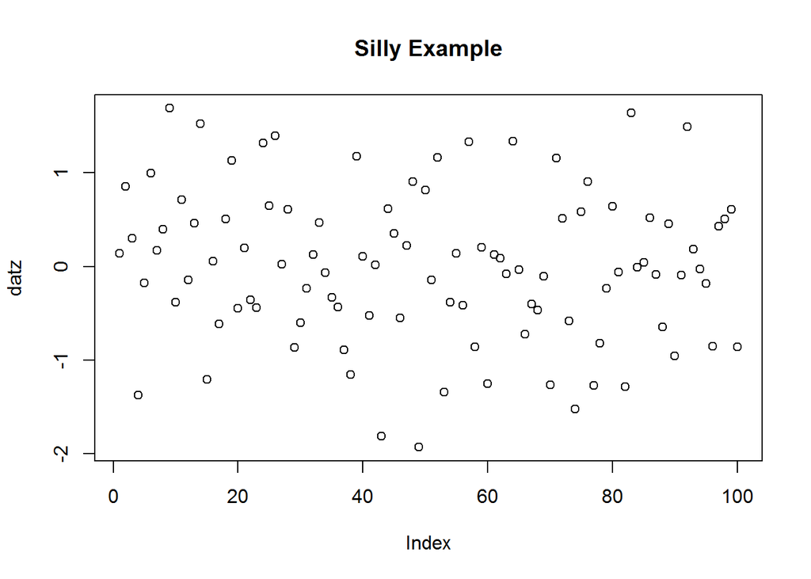

```r
ScatterPlot(datz = rnorm(100), title = "Silly Example")
```